# CMPINF 2130 Summer 2021 - Week 08

Composite graphics

Dr. Joseph P. Yurko

July 2021

## Load packages

```r
library(tidyverse)
library(ggExtra)
```

## Iris data

Create a scatter plot between the Sepal variables.

```r
iris %>%
  ggplot(mapping = aes(x = Sepal.Length, y = Sepal.Width)) +
  geom_point(alpha = 0.5, size = 3) +
  theme_bw()
```

[output not shown]

Creating a composite graphic such as a scatter plot combined with histograms is challenging. We will use the `ggMarginal()` function from `ggExtra` to create the **composite graphic** or the *marginal+scatter* plot.

First, let’s assign the scatter plot to a variable.

```r
p <- iris %>%
  ggplot(mapping = aes(x = Sepal.Length, y = Sepal.Width)) +
  geom_point(alpha = 0.5, size = 3) +
  theme_bw()
```

We can visualize the plot by printing or just displaying it.

```r
print( p )
```

[output not shown]

Or:

```r
p
```

[output not shown]

Modify the scatter plot by combining or adding the marginal histograms outside of the graphical window.

```r
p1 <- ggMarginal(p, type = 'histogram')
```

Print `p1` to visualize the marginal + scatter plot.

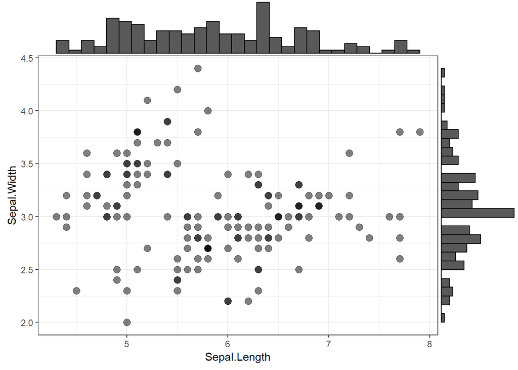

```r
print( p1 )
```

We could instead use kernel density estimates for the marginal distributions.

```r
p2 <- ggMarginal(p, type = 'density')
```

Visualize the marginal + scatter plot again but with kde.

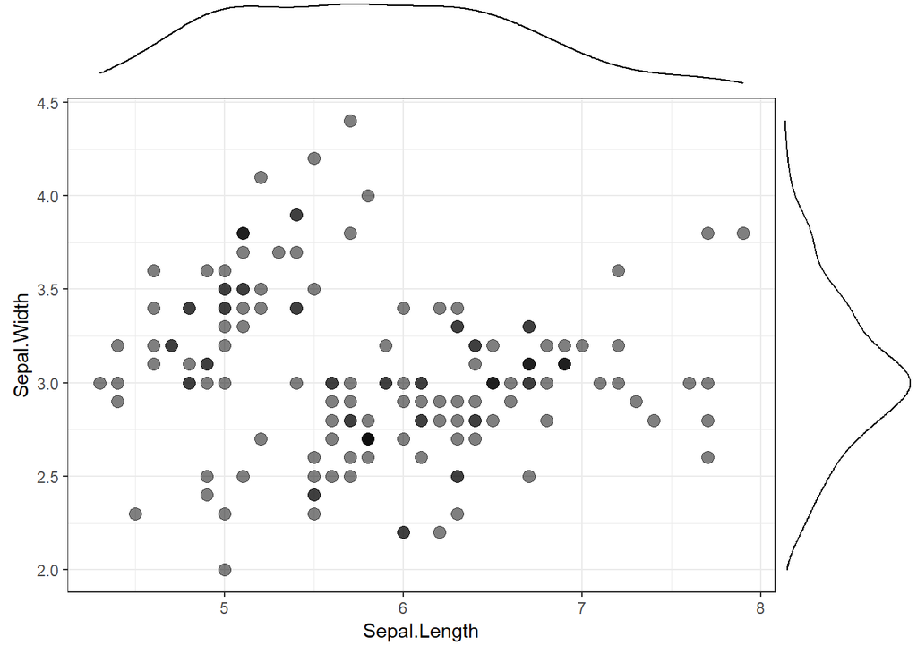

```r
print( p2 )
```

If we are interested in the marginal summary statistics we can use boxplots outside the graphical window.

```r
p3 <- ggMarginal(p, type = 'boxplot')
```

Visualize again.

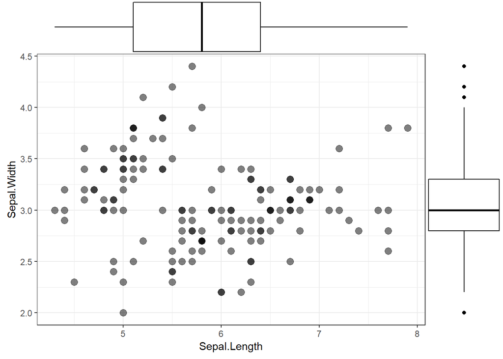

```r
print( p3 )
```

We could instead use a 2D joint density estimate to represent the joint distribution.

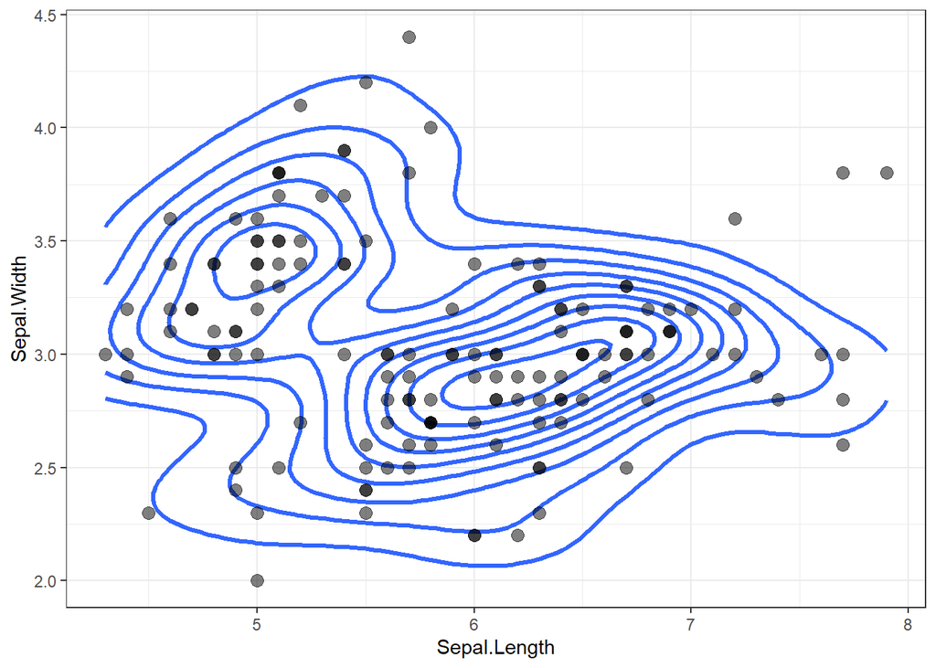

```r
sepal_2d <- iris %>%
  ggplot(mapping = aes(x = Sepal.Length, y = Sepal.Width)) +
  geom_density_2d(size = 1.1) +
  geom_point(alpha = 0.5, size = 3) +
  theme_bw()

print( sepal_2d )
```

Add in the marginal distributions via kde plots.

```r
sepal_2d_marg <- ggMarginal(sepal_2d, type = 'density')
```

Visualize.

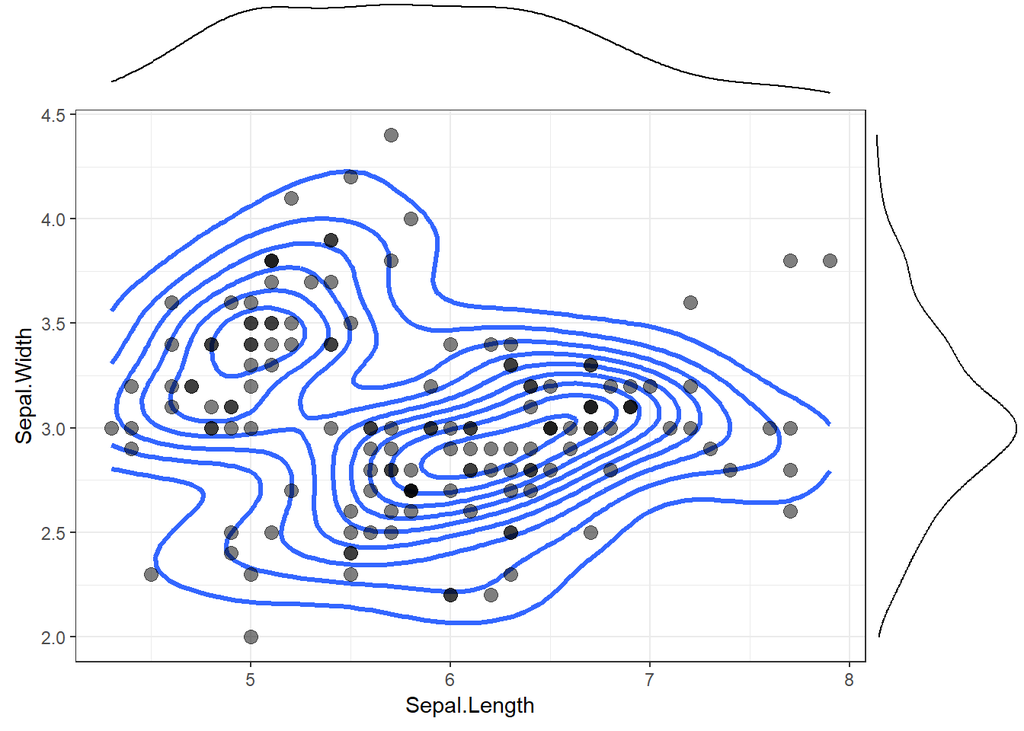

```r
print( sepal_2d_marg )
```

We can also color by a categorical with the joint distribution **and** the marginal.

```r
sepal_species <- iris %>%
  ggplot(mapping = aes(x = Sepal.Length, y = Sepal.Width,
                       color = Species)) +
  geom_density_2d(size = 1.1) +
  geom_point(alpha = 0.5, size = 3) +
  ggthemes::scale_color_colorblind() +
  theme_bw() +
  theme(legend.position = "bottom")
```

Add in the marginal grouped density plots.

```r
sepal_species_marg <- ggMarginal(sepal_species, type = 'density', groupColour = TRUE )
```

Visualize the grouped joint and marginal densities.

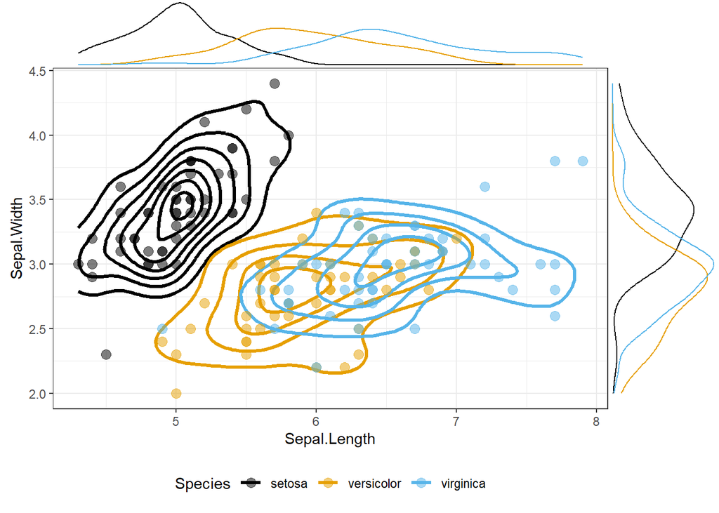

```r
print( sepal_species_marg )
```

We could also fill and color boxplots in the marginals if we would prefer.

```r
sepal_species_box <- ggMarginal( sepal_species, type = 'boxplot',
                                 groupFill = TRUE, groupColour = TRUE,
                                 xparams = list(alpha = 0.35),
                                 yparams = list(alpha = 0.35))
```

Visualize.

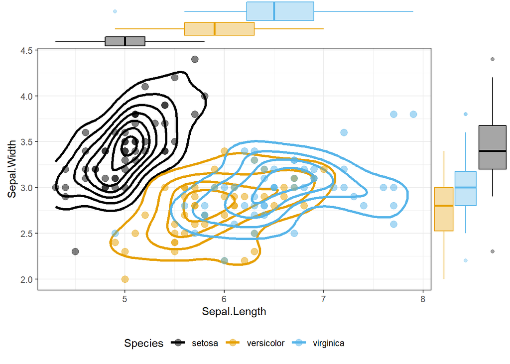

```r
print( sepal_species_box )
```